# Tutorial on Freelisting Analysis With R

RWH

2026-03-30

### 1 About this Tutorial

We will focus on the “cavities” dataset that includes data from $N = 200$ English-speaking adults collected between February 2020 and October 2022. All participants provided verbal informed consent and received a $5 gift card for their participation.

Each participant was asked to “list all the thoughts and feelings that come to mind when you hear *dental cavity*”

All responses are deidentified, and the study was originally covered by the TJU IRB.

### 2 Analysis overview

This tutorial covers 5 steps of analysis

1. Installing the packages necessary for the code to work - **this needs only to be done once**
2. Loading data from Excel into R and preparing it for analysis
3. Performing salience computations as well as other summary statistics
4. Outputting the results to Excel
5. (Optional) graphing the results in R

### 3 Installing AnthroTools

`AnthroTools` is a package developed by Purzycki and Jamieson-Lane. Instructions on downloading and installing it are found [here](https://github.com/alastair-JL/AnthroTools). That link also contains citations of the package authors’ work as well as some important freelisting publications.

Because it is not available on CRAN, the main R repository, it must be installed from GitHub, which relies on the `devtools` package. The code below will install (or update) `devtools`, load the package and install `AnthroTools`

```r
install.packages("devtools")
library("devtools")
install_github('alastair-JL/AnthroTools')
```

It is only necessary install `AnthroTools` once. From then on, the package can be loaded simply by calling the library statement:

```r
library(AnthroTools)
```

### 4 Setting up the analysis

You will need two other packages for this code to work:

```r
library(tidyr)
library(dplyr)
```

If you do not have these installed, both are available via the [tidyverse](https://tidyverse.org/)

#### 4.1 Formatting your .csv

The easiest way to analyze data for freelisting in R is to format a .csv file in the following way:

| Participant | Term1 | Term2 | … | Term_N |
| --- | --- | --- | --- | --- |
| 1 | SMELL | PAIN | … | GROSS |
| 2 | HOLE | PAIN | … |  |
| 3 | PAIN | SWOLEN | … | HELP |
| . | … | … | … | … |
| . | … | … | … | … |
| n | FOUL | BROKEN | … | SMILE |

So the only columns you should have in your spreadsheet are the first column containing Participant ID’s followed by a column for the first term in the participant’s lists, second term, etc. You should have as many columns as there are terms in the **longest list**

Important: **leave cells in the spreadsheet blank if a participant’s list does not utilize all columns**

#### 4.2 Reading in data

This is usually the most difficult part for beginners. In order to read data into R, you must either

1. Specify the full path to the file
2. Create a special folder with the file for your project, and set this folder as your working directory. In RStudio, you can do this by clicking on the `Files` tab and navigating to your working director. To then **set your working directory** click on the gear icon and select `Set as working directory`. You can then simply reference the file name, without the full path in any `read` function

#### 4.3 Example with full path to file

So that you have some data to work with easily, the next block of code downloads data from GitHub and loads it:

```r
cav <- read.csv("https://rickhass.github.io/CAV_fem.csv?raw=true", stringsAsFactors = F,
                na.strings = c(""," ","  "))
```

If you have data on your hard drive, you have to type in the path to the directory. For example, for Mac users if a file is in your home directory, in a subfolder labeled “Freelisting”, you would type this (which won’t work!)

```r
# load the dataset
d <- read.csv("~/Freelisting/CAV_fem.csv", stringsAsFactors = F, na.strings = c(""," ","  "))
```

In the above, the `read.csv` function expects a **string** denoting the path to the file and the file name (`"~/Freelisting/CAV_fem.csv"`). The other arguments are personal defaults to guarantee that blank cells actually get interpreted as blank in R.

**If you were already using the `Freelisting` folder as your working directory, you would only need to type `"CAV_fem.csv"` above.**

#### 4.4 Quick look at the dataset

There are more effective ways to do this in RStudio, but below, we can see the data first six rows in the dataset (corresponding to the first $6$ female participants) printed to a table:

Data for the first 6 Participants

| Participant | Term1 | Term2 | Term3 | Term4 | Term5 | Term6 | Term7 | Term8 | Term9 | Term10 |
| --- | --- | --- | --- | --- | --- | --- | --- | --- | --- | --- |
| 2 | PAIN | steel | PAYMENT | DIET | NA | NA | NA | NA | NA | NA |
| 4 | preventable | PAIN | PAYMENT | NA | NA | NA | NA | NA | NA | NA |
| 5 | something wrong with tooth | born with weak teeth | need extra vitamins | dental sealing | NA | NA | NA | NA | NA | NA |
| 6 | TREATMENT | neutral | sticker | I don’t know | NA | NA | NA | NA | NA | NA |
| 7 | PAIN | NA | NA | NA | NA | NA | NA | NA | NA | NA |
| 9 | FEAR | PAIN | PAYMENT | TREATMENT | NA | NA | NA | NA | NA | NA |

As you can see, Participant 2 has given $4$ responses, while participant 7 has only given $1$ response (`PAIN`).

**Whenever you see `NA` that is `R`’s symbol for blank or missing.** That is what we want here, as participants have different numbers of responses.

### 5 Cleaning and reformatting the data

Before this data set can be processed with `AnthroTools` it must be converted from **wide** format to **long** format. This means that we need a data set with only three columns:

| participant | order | term |
| --- | --- | --- |
| 1 | 1 | PAIN |
| 1 | 2 | STEEL |
| 1 | 3 | PREVENTABLE |
| … | … | … |

Notice that there is only one response per row. The Participant columns still labels which participant gave the response, but now we have a new column called `order` that will tell us in what order the participant said the response. Remember, the order matters for salience calculations.

To make this happen, we’ll use the `pivot_longer()` function in the `tidyr` package:

```r
d.long <- cav |>
  pivot_longer(!Participant, names_to = "order", values_to = "term", values_drop_na = TRUE) |>
  as.data.frame()
```

Before showing you the data, let’s clean it up even more. First, we will make all terms lowercase and strip out any remaining white space. We do this to make sure that we don’t artificially have two different terms that are the same (e.g., PAIN and Pain)

```r
# Make all terms lowercase
d.long$term <- trimws(tolower(d.long$term))
```

Finally, we need to convert the `order` column from a label (Term1, etc.) to a number

```r
# Convert from the "Term.1, etc." to integers 1,2,3,4...
d.long$order <- as.numeric(factor(d.long$order, levels = paste("Term",seq(1:11), sep = ""), ordered = T))
```

And voila! We have a nice clean dataset. Here’s the first 7 rows, which show the responses from the first two participants

First 7 rows in the long dataset

| Participant | order | term |
| --- | --- | --- |
| 2 | 1 | pain |
| 2 | 2 | steel |
| 2 | 3 | payment |
| 2 | 4 | diet |
| 4 | 1 | preventable |
| 4 | 2 | pain |
| 4 | 3 | payment |

### 6 Computing Salience for a single group

Finally, we are ready to put `AnthroTools` to work. This will take several steps due to how the package works

#### 6.1 Salience Per List and Per Code

1. First, we compute the salience within each list using `CalculateSalience`. This essentially just adds a 4th column to the existing dataset, though we save it as a new data frame
2. Then, using `SalienceByCode` we compute salience per term, which is what we want

An important note about the `dealWithDoubles` argument to `SalienceByCode`: we have set it to `"SUM"` which will allow a participant to say the same term twice or more in their list. Setting the argument to `"MAX"` will ignore subsequent uses of the same term within a single list.

```r
## Get individual salience per term, per respondent
d.Sal.term <- CalculateSalience(d.long, Order = "order", Subj = "Participant",
                                CODE = "term", Rescale = TRUE)
# get overall salience, sum over respondents
d.Salience <- SalienceByCode(d.Sal.term, CODE = "term",
                             Subj = "Participant", dealWithDoubles = "SUM")
```

If we stopped there, we would have a wonky dataset. We’ll now make it look nicer by doing the following:

1. Alphabetizing the terms
2. Computing each term’s mean order in a given list and the proportion of lists in which it appears
3. Finally, we add in the salience computation from before and look at the results

```r
# get per term average rank in lists and Frequency of lists containing term
# first sort CODEs alphabetically
d.Salience <- d.Salience[order(d.Salience$CODE), ]

## now organize into a data frame with
## Term
## Mean order in the list
## proportion of lists featuring the term
## Smith's S for salience
summary.d <- d.long %>%
  group_by(term) %>%
  summarize(mean = mean(order), proportion = n() / nrow(cav))

# add in the salince per term
summary.d$Salience <- d.Salience$SmithsS
```

Below are the first 10 terms in the `summary.d` data frame:

First 10 terms, alphabetically

| term | mean | proportion | Salience |
| --- | --- | --- | --- |
| adequate care | 8.0 | 0.0116279 | 0.0006342 |
| age | 5.5 | 0.0232558 | 0.0029145 |
| appointment | 3.0 | 0.0116279 | 0.0019380 |
| bad habits | 3.0 | 0.0116279 | 0.0019380 |
| bad oral health | 4.0 | 0.0116279 | 0.0011628 |
| bad teeth | 4.0 | 0.0116279 | 0.0011628 |
| born with weak teeth | 2.0 | 0.0116279 | 0.0034884 |
| braces | 2.0 | 0.0116279 | 0.0038760 |
| cavities | 3.0 | 0.0116279 | 0.0023256 |
| cavity | 2.0 | 0.0116279 | 0.0034884 |

### 7 Exporting results to a .csv file

Most people use Excel to make graphical displays, and the data can be written to a .csv using this code, which will deposit the .csv file in your working directory. You can confirm where your working director is located by typing `getwd()` at the command prompt in the console.

```r
write.csv(summary.d, "My_Data.csv", row.names = FALSE)
```

Writing to an `.xlsx` file is more complicated, but it is easy to output as many `.csv` files as you like and copy and paste them into an Excel workbook.

### 8 Computing Salience for a multiple groups

Though `AnthroTools` has a native option for dealing with subgroups. The original dataset you just loaded and analyzed is a subgroup analysis of a larger dataset. We’ll now demonstrate how you might read in a dataset with demographic information and create subsets to analyze. This is far more flexible than using the `AnthroTools` function.

First, let’s get the data for all participants. The previous dataset was only female respondents

```r
cav_group <- read.csv("https://rickhass.github.io/CAV_all_demo.csv?raw=true", stringsAsFactors = F, na.strings = c(""," ","  "))
```

This dataframe is very similar to the other one, but now we have three new columns

- `Age.at.time.of.interview`
- `generation`: a categorical variable based on age
- `Gender` a numerically coded variable with 0 = female, 1 = male, 2 = nonbinary

#### 8.1 Creating subsets for analysis

To arrive at the same dataset as you loaded in at the beginning of the tutorial, we use two `dplyr` functions: `filter`, which selects specific rows of the dataset (below, it will be those for which `Gender == 0`, that is, females), and `select` which picks out the columns we want. See the help file for `dplyr::select` for more information on listing columns.

```r
cav_fem <- cav_group |>
  filter(Gender == 0) |>
  select(Participant, Term.1:Term.11)
```

The only difference between this dataset and the previous one, is that we have a column for `Term.11` but it is all `NA`. That is because none of the female respondents gave 11 terms, but the column is still included. This will not affect the code that pivots this data to the longer version.

```r
d.long.fem <- cav_fem |>
  pivot_longer(!Participant, names_to = "order", values_to = "term", values_drop_na = TRUE) |>
  as.data.frame()
```

Finally, it is possible to filter on several variables, which one often does with freelisting. For example, if we wanted only female millennials, we’d alter the code above using the `&` operator:

```r
cav_fem_mil <- cav_group |>
  filter(Gender == 0 & generation == "Millennial") |>
  select(Participant, Term.1:Term.11)
```

In English, the above translates to filter the dataset down to rows for which it is true that gender = 0 (female) AND generation is Millennial. We end up with $n = 32$ out of the original $N = 200$.

There are many other sub-groups one could make with the `filter` function and it simply depends on the scope of your analysis, and what demographic variables you collected.

### 9 Making Scree Plots

Though it is very easy to make a scree plot using Excel or the program of your liking, you can also make it a seamless part of the R freelisting analysis. We’ll present to ways to do this. First, we’ll use “base” `R`, meaning we’ll use the `plot()` function originally created for `R` and then illustrate how to make a slightly fancier plot with a newer method.

#### 9.1 Using plot()

To make the scree plot, we first need to sort the data in decreasing order of salience

```r
scree.data <- summary.d[order(summary.d$Salience, decreasing = TRUE), ]
```

Now we will plot using R’s native plot function

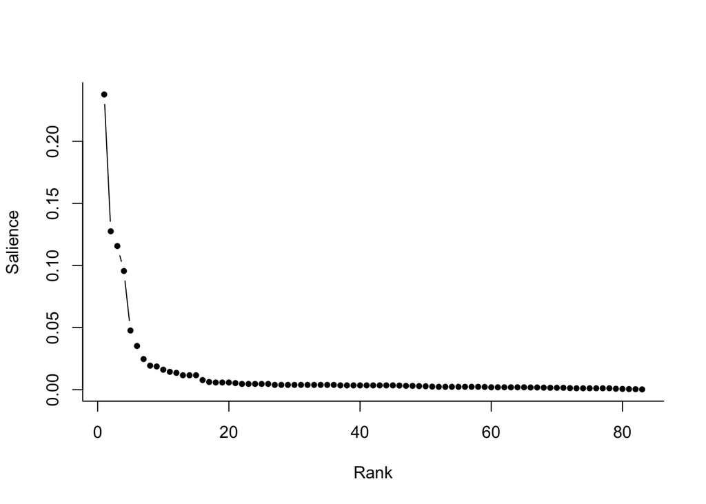

```r
plot(scree.data$Salience, type = "b", ylab = "Salience", xlab = "Rank", bty = "l", pch =20)
```

We can see a clear elbow very early on, so let’s zoom in and add terms to the plot.

The way this is done is in different commands. `R` draws the plot first, then adds the text via the `text()` function. We use the `srt` argument to angle the text to `45` degrees so we can see the words

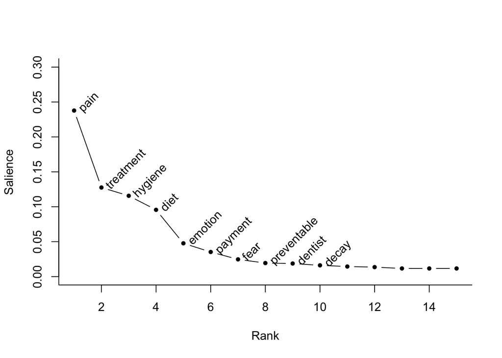

```r
plot(x = seq(1:15), y = scree.data$Salience[1:15], type = "b", ylab = "Salience", xlab = "Rank", bty = "l", pch =20, ylim = c(0,.3))

text(x = seq(1:10), y = scree.data$Salience[1:10],
     labels = scree.data$term[1:10],
     pos = 4,
     srt = 45
     )
```

From here, we can choose our interpretation of the most salient terms, which could be the first 4, the first 5 or even all the terms seen here.

#### 9.2 Using ggplot2 for Scree Plots and other Visualizations

The `ggplot2` package, also distributed with the Tidyverse has many more plotting options built in.

Here’s how we might make a scree plot with labels using that method

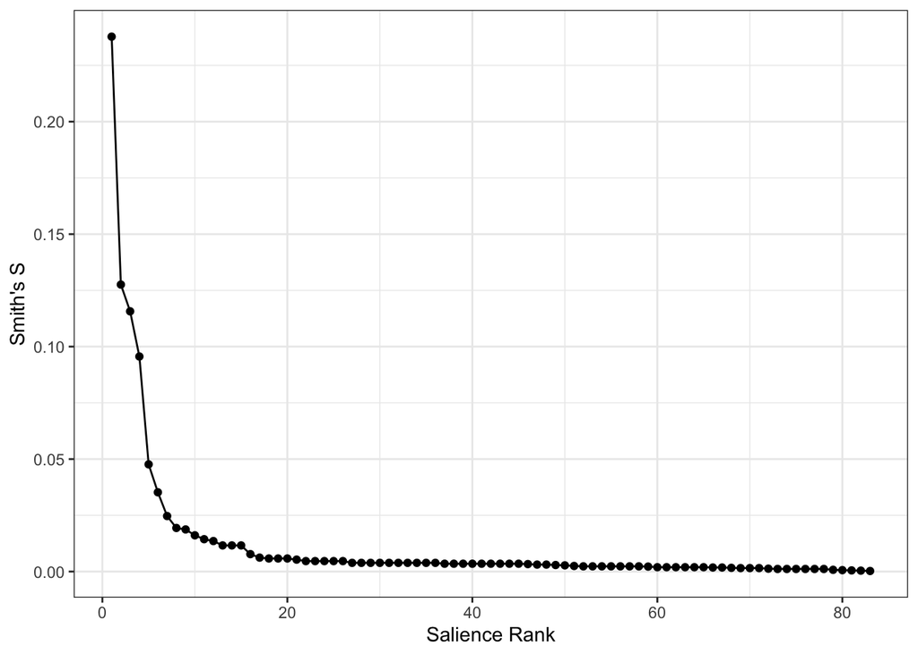

```r
library(ggplot2)

scree.data$rank <- seq(1:nrow(scree.data))

ggplot(aes(x = rank, y = Salience), data = scree.data) +
  geom_line() +
  geom_point() +
  xlab("Salience Rank") +
  ylab("Smith's S") +
  theme_bw()
```

And adding the labels

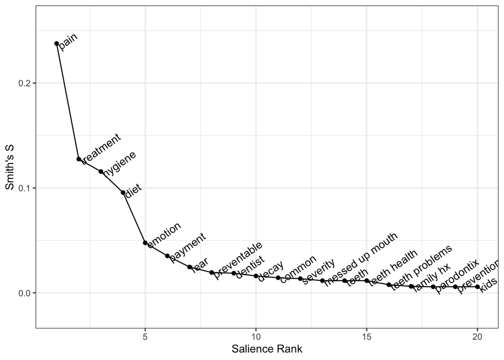

```r
scree.20 <- scree.data[1:20,]

ggplot(aes(x = rank, y = Salience, label = term), data = scree.20) +
  geom_line() +
  geom_point() +
  geom_text(angle = 35, hjust = "left", vjust = "top") +
  coord_cartesian(ylim = c(-0.02,.26)) +
  xlab("Salience Rank") +
  ylab("Smith's S") +
  theme_bw()
```

Continued experimentation with geom_text can push the labels to different positions.

### 10 Other Resources

- R and RStudio are very well documented. One of the best overviews of data cleaning and `tidy` code is [Hadley Wickham’s R For Data Science (2nd ed)](https://r4ds.hadley.nz/)
- For more on using `ggplot2` see [Wickham, Navarro, and Pedersen](https://ggplot2-book.org/index.html)
- For some statistical perspective as well as some nice examples of coding in base R, see [Fox and Weisberg (3rd edition)](https://collegepublishing.sagepub.com/products/an-r-companion-to-applied-regression-3-246125)